# CaseStuday1

Chuan Liu

2025-04-07

## Case Study 1: How does a bike-share navigate speedy success?

#### ASK：Questions to be addressed

1. How do annual members and casual riders use Cyclistic bikes differently?
2. Why would casual riders buy Cyclistic annual memberships?
3. How can Cyclistic use digital media to influence casual riders to become members?

#### Prepare

1.Access data, this is public data from website: https://divvy-tripdata.s3.amazonaws.com/index.html, given by the class, we will take 2019-Q1 and 2020-Q1 cyclistic data.

2.The data consists of 2 csv files. The files for the 2019-Q1 and 2020-Q1

3.The data is first-party data collected by Cyclist so there is low chance of bias but due to it being the companies own data the credibility is very high.

4.The data is open source and covered by licence : https://divvybikes.com/data-license-agreement

#### Process

We will start our analyze by preparing the R system first:

We import our Data sets to R system and check the column name for each column:

```
##  [1] "trip_id"           "start_time"        "end_time"
##  [4] "bikeid"            "tripduration"      "from_station_id"
##  [7] "from_station_name" "to_station_id"     "to_station_name"
## [10] "usertype"          "gender"            "birthyear"
```

```
##  [1] "ride_id"            "rideable_type"      "started_at"
##  [4] "ended_at"           "start_station_name" "start_station_id"
##  [7] "end_station_name"   "end_station_id"     "start_lat"
## [10] "start_lng"          "end_lat"            "end_lng"
## [13] "member_casual"
```

We found that some of the corresponding data in two csv files has different names, so we will need to change these names to the same one:

Next, we check the data character for each column in two files, we found that the character of “ride_id” and “rideable_type” are different between to files, we need fix this too:

```
## spc_tbl_ [365,069 × 12] (S3: spec_tbl_df/tbl_df/tbl/data.frame)
##  $ ride_id           : num [1:365069] 21742443 21742444 21742445 21742446 21742447 ...
##  $ started_at        : chr [1:365069] "2019-01-01 0:04:37" "2019-01-01 0:08:13" "2019-01-01 0:13:23" "2019-01-01 0:13:45" ...
##  $ ended_at          : chr [1:365069] "2019-01-01 0:11:07" "2019-01-01 0:15:34" "2019-01-01 0:27:12" "2019-01-01 0:43:28" ...
##  $ rideable_type     : num [1:365069] 2167 4386 1524 252 1170 ...
##  $ tripduration      : num [1:365069] 390 441 829 1783 364 ...
##  $ start_station_id  : num [1:365069] 199 44 15 123 173 98 98 211 150 268 ...
##  $ start_station_name: chr [1:365069] "Wabash Ave & Grand Ave" "State St & Randolph St" "Racine Ave & 18th St" "California Ave & Milwaukee Ave" ...
##  $ end_station_id    : num [1:365069] 84 624 644 176 35 49 49 142 148 141 ...
##  $ end_station_name  : chr [1:365069] "Milwaukee Ave & Grand Ave" "Dearborn St & Van Buren St (*)" "Western Ave & Fillmore St (*)" "Clark St & Elm St" ...
##  $ member_casual     : chr [1:365069] "Subscriber" "Subscriber" "Subscriber" "Subscriber" ...
##  $ gender            : chr [1:365069] "Male" "Female" "Female" "Male" ...
##  $ birthyear         : num [1:365069] 1989 1990 1994 1993 1994 ...
##  - attr(*, "spec")=
##   .. cols(
##   ..   trip_id = col_double(),
##   ..   start_time = col_character(),
##   ..   end_time = col_character(),
##   ..   bikeid = col_double(),
##   ..   tripduration = col_number(),
##   ..   from_station_id = col_double(),
##   ..   from_station_name = col_character(),
##   ..   to_station_id = col_double(),
##   ..   to_station_name = col_character(),
##   ..   usertype = col_character(),
##   ..   gender = col_character(),
##   ..   birthyear = col_double()
##   .. )
##  - attr(*, "problems")=<externalptr>
```

```
## spc_tbl_ [426,887 × 13] (S3: spec_tbl_df/tbl_df/tbl/data.frame)
##  $ ride_id           : chr [1:426887] "EACB19130B0CDA4A" "8FED874C809DC021" "789F3C21E472CA96" "C9A388DAC6ABF313" ...
##  $ rideable_type     : chr [1:426887] "docked_bike" "docked_bike" "docked_bike" "docked_bike" ...
##  $ started_at        : chr [1:426887] "2020-01-21 20:06:59" "2020-01-30 14:22:39" "2020-01-09 19:29:26" "2020-01-06 16:17:07" ...
##  $ ended_at          : chr [1:426887] "2020-01-21 20:14:30" "2020-01-30 14:26:22" "2020-01-09 19:32:17" "2020-01-06 16:25:56" ...
##  $ start_station_name: chr [1:426887] "Western Ave & Leland Ave" "Clark St & Montrose Ave" "Broadway & Belmont Ave" "Clark St & Randolph St" ...
##  $ start_station_id  : num [1:426887] 239 234 296 51 66 212 96 96 212 38 ...
##  $ end_station_name  : chr [1:426887] "Clark St & Leland Ave" "Southport Ave & Irving Park Rd" "Wilton Ave & Belmont Ave" "Fairbanks Ct & Grand Ave" ...
##  $ end_station_id    : num [1:426887] 326 318 117 24 212 96 212 212 96 100 ...
##  $ start_lat         : num [1:426887] 42 42 41.9 41.9 41.9 ...
##  $ start_lng         : num [1:426887] -87.7 -87.7 -87.6 -87.6 -87.6 ...
##  $ end_lat           : num [1:426887] 42 42 41.9 41.9 41.9 ...
##  $ end_lng           : num [1:426887] -87.7 -87.7 -87.7 -87.6 -87.6 ...
##  $ member_casual     : chr [1:426887] "member" "member" "member" "member" ...
##  - attr(*, "spec")=
##   .. cols(
##   ..   ride_id = col_character(),
##   ..   rideable_type = col_character(),
##   ..   started_at = col_character(),
##   ..   ended_at = col_character(),
##   ..   start_station_name = col_character(),
##   ..   start_station_id = col_double(),
##   ..   end_station_name = col_character(),
##   ..   end_station_id = col_double(),
##   ..   start_lat = col_double(),
##   ..   start_lng = col_double(),
##   ..   end_lat = col_double(),
##   ..   end_lng = col_double(),
##   ..   member_casual = col_character()
##   .. )
##  - attr(*, "problems")=<externalptr>
```

Now we have two files identical， we can now combine two files into one file by simply add all rows together and delete the non-overlapping columns of a table , and check the information in our new file:

```
## [1] "ride_id"            "started_at"         "ended_at"
## [4] "rideable_type"      "start_station_id"   "start_station_name"
## [7] "end_station_id"     "end_station_name"   "member_casual"
```

```
## [1] 791956
```

```
## [1] 791956      9
```

```
## # A tibble: 6 × 9
##   ride_id  started_at ended_at rideable_type start_station_id start_station_name
##   <chr>    <chr>      <chr>    <chr>                    <dbl> <chr>
## 1 21742443 2019-01-0… 2019-01… 2167                       199 Wabash Ave & Gran…
## 2 21742444 2019-01-0… 2019-01… 4386                        44 State St & Randol…
## 3 21742445 2019-01-0… 2019-01… 1524                        15 Racine Ave & 18th…
## 4 21742446 2019-01-0… 2019-01… 252                        123 California Ave & …
## 5 21742447 2019-01-0… 2019-01… 1170                       173 Mies van der Rohe…
## 6 21742448 2019-01-0… 2019-01… 2437                        98 LaSalle St & Wash…
## # ℹ 3 more variables: end_station_id <dbl>, end_station_name <chr>,
## #   member_casual <chr>
```

```
## tibble [791,956 × 9] (S3: tbl_df/tbl/data.frame)
##  $ ride_id           : chr [1:791956] "21742443" "21742444" "21742445" "21742446" ...
##  $ started_at        : chr [1:791956] "2019-01-01 0:04:37" "2019-01-01 0:08:13" "2019-01-01 0:13:23" "2019-01-01 0:13:45" ...
##  $ ended_at          : chr [1:791956] "2019-01-01 0:11:07" "2019-01-01 0:15:34" "2019-01-01 0:27:12" "2019-01-01 0:43:28" ...
##  $ rideable_type     : chr [1:791956] "2167" "4386" "1524" "252" ...
##  $ start_station_id  : num [1:791956] 199 44 15 123 173 98 98 211 150 268 ...
##  $ start_station_name: chr [1:791956] "Wabash Ave & Grand Ave" "State St & Randolph St" "Racine Ave & 18th St" "California Ave & Milwaukee Ave" ...
##  $ end_station_id    : num [1:791956] 84 624 644 176 35 49 49 142 148 141 ...
##  $ end_station_name  : chr [1:791956] "Milwaukee Ave & Grand Ave" "Dearborn St & Van Buren St (*)" "Western Ave & Fillmore St (*)" "Clark St & Elm St" ...
##  $ member_casual     : chr [1:791956] "Subscriber" "Subscriber" "Subscriber" "Subscriber" ...
```

```
##    ride_id           started_at          ended_at         rideable_type
##  Length:791956      Length:791956      Length:791956      Length:791956
##  Class :character   Class :character   Class :character   Class :character
##  Mode  :character   Mode  :character   Mode  :character   Mode  :character
##
##
##
##
##  start_station_id start_station_name end_station_id  end_station_name
##  Min.   :  2.0    Length:791956      Min.   :  2.0   Length:791956
##  1st Qu.: 77.0    Class :character   1st Qu.: 77.0   Class :character
##  Median :174.0    Mode  :character   Median :174.0   Mode  :character
##  Mean   :204.4                       Mean   :204.4
##  3rd Qu.:291.0                       3rd Qu.:291.0
##  Max.   :675.0                       Max.   :675.0
##                                      NA's   :1
##  member_casual
##  Length:791956
##  Class :character
##  Mode  :character
##
##
##
##
```

#### Data Clean

First, we change the information in each cell on column “number_casual” to unified content, avoid any misunderstanding:

```
##
## casual member
##  71643 720313
```

Then, we split the “started_date” into details by adding some new columns (month,day,year,day of week) and calculate the total ride length for each ride and show it in a new column named “ride_length”:

Next, The data frame includes a few hundred entries when bikes were taken out of docks and checked for quality by Divvy or ride_length was negative, so we need to remove them:

#### Analyze

Descriptive analysis on ride_length, and compare members and casual users by max,min,mean,media separately:

```
##     Min.  1st Qu.   Median     Mean  3rd Qu.     Max.
##        1      331      539     1189      912 10628422
```

```
##   q1_all$member_casual q1_all$ride_length
## 1               casual          5370.7685
## 2               member           795.1324
```

```
##   q1_all$member_casual q1_all$ride_length
## 1               casual               1393
## 2               member                508
```

```
##   q1_all$member_casual q1_all$ride_length
## 1               casual           10628422
## 2               member            6096428
```

```
##   q1_all$member_casual q1_all$ride_length
## 1               casual                  2
## 2               member                  1
```

Then see the average ride time by each day for members vs casual users ordered by day of week:

```
##    q1_all$member_casual q1_all$started_day_of_week q1_all$ride_length
## 1                casual                     Monday          4750.7627
## 2                member                     Monday           822.2134
## 3                casual                    Tuesday          4560.8190
## 4                member                    Tuesday           769.4416
## 5                casual                  Wednesday          4480.3724
## 6                member                  Wednesday           711.9838
## 7                casual                   Thursday          8450.1557
## 8                member                   Thursday           707.2093
## 9                casual                     Friday          6088.9402
## 10               member                     Friday           796.6713
## 11               casual                   Saturday          4946.4956
## 12               member                   Saturday           973.7094
## 13               casual                     Sunday          5059.1813
## 14               member                     Sunday           972.1609
```

Generate a table for analyze ridership data by type and weekday:

```
## # A tibble: 14 × 4
## # Groups:   member_casual [2]
##    member_casual weekday number_of_rides average_duration
##    <chr>         <ord>             <int>            <dbl>
##  1 casual        Sun               18652            5059.
##  2 casual        Mon                5591            4751.
##  3 casual        Tue                7311            4561.
##  4 casual        Wed                7690            4480.
##  5 casual        Thu                7147            8450.
##  6 casual        Fri                8013            6089.
##  7 casual        Sat               13473            4946.
##  8 member        Sun               60197             972.
##  9 member        Mon              110430             822.
## 10 member        Tue              127974             769.
## 11 member        Wed              121902             712.
## 12 member        Thu              125228             707.
## 13 member        Fri              115168             797.
## 14 member        Sat               59413             974.
```

## Including Plots

Plot 1: Visualize the number of rides by rider type

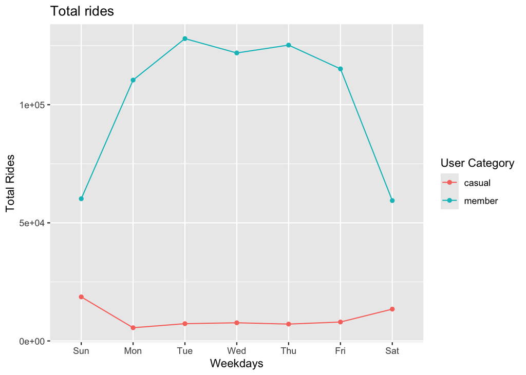

Plot 2: Visualization for average duration

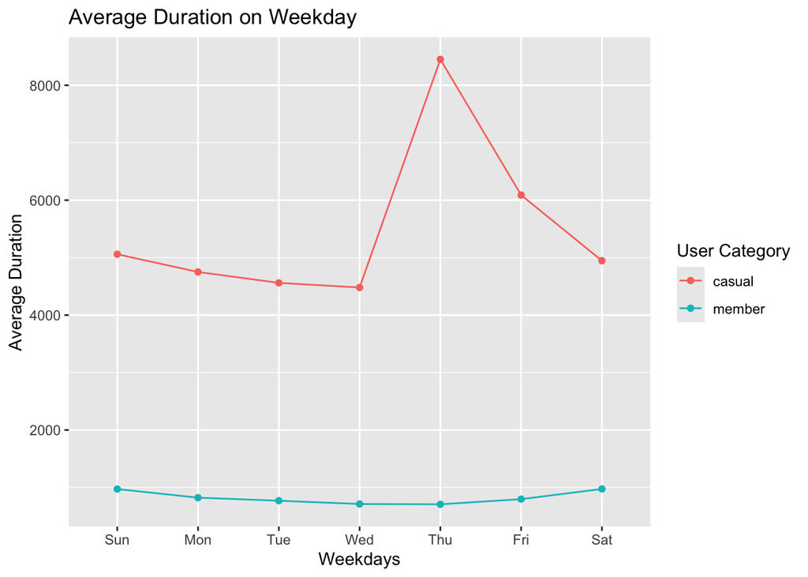

#### Share

1.How do annual members and casual riders use Cyclistic bikes differently?

As illustrated in the figures above, casual riders have higher “average_ride_length”, but with less total “number_of_rides”. Casual riders tend to have a higher average ride length, indicating strong demand and high potential for conversion to membership.

3. How can Cyclistic use digital media to influence casual riders to become members?

Focus digital media efforts on areas with high casual rider activity , and offer membership discounts based on “average_ride_length” to incentive conversion.